# Assignment 2

Claudeon Susanto

2022-09-28

## Question 1

### Question 1.1

```r
box_muller <- function(n) {

  # function to generate two random variables
  box_muller2 <- function(i) {
    u <- runif(2, min=0, max=1);
    x1 <- sqrt(-2*log(u[1]))*cos(2*pi*u[2])
    x2 <- sqrt(-2*log(u[1]))*sin(2*pi*u[2])
    c(x1,x2)
  }

  # apply n/2 or (n+1)/2 times and return the result as a vector
  apply_times <- ifelse(n%%2==0, n/2, (n+1)/2)
  c(sapply(1:apply_times,box_muller2))[1:n]

}
```

### Question 1.2

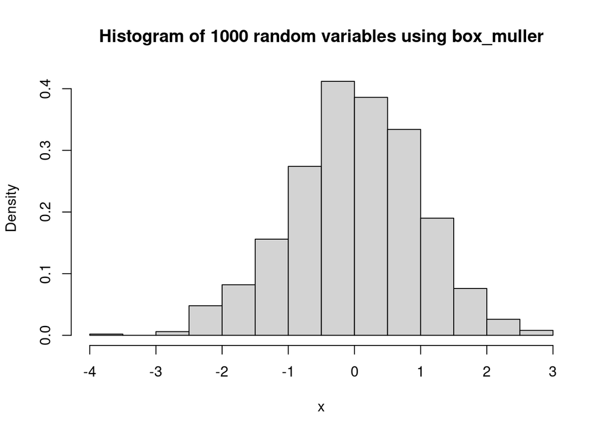

```r
box_mueller_output <- box_muller(1000)
hist(box_mueller_output, probability=TRUE,
     xlab="x", main="Histogram of 1000 random variables using box_muller")
```

### Question 1.3

If the algorithm is working correctly, we would get a vector $(x_1, x_2, \dots, x_{1000})$ where $X_i \sim \mathcal{N}(0,1)$ as the output for question 1.2.

There are two ways to verify the algorithm:

- Use the functions `mean` and `sd` to test if the 1000 random numbers generated have mean and SD close to 0 and 1 respectively (within +-0.05), if the results are close to the expected value, the algorithm should work correctly. If the results are far away from 0 and 1, the algorithm is not working properly.

```r
mean(box_mueller_output)
## [1] 0.01227302
sd(box_mueller_output)
## [1] 0.9741818
```

- Plot the PDF of $\mathcal{N}(0,1)$ on top of the histogram. If the PDF curve largely fits the histogram and have similar shapes, the algorithm should be working correctly. If the histogram and PDF curve have different shapes or do not fit, the algorithm is not working correctly.

[figure not shown]

```r
# plot histogram
hist(box_mueller_output, probability=TRUE,
     xlab="x", main="CDF superimposed on histogram")

# plot PDF of N(0,1)
points(seq(min(box_mueller_output), max(box_mueller_output), by=0.01),dnorm(seq(min(box_mueller_output),max(box_mueller_output),by=0.01)),type="l")
```

## Question 2

Observe that the URL to get the png is of the format `www.nea.gov.sg/docs/default-source/rain-area-240km/dpsri_240km_YYYYMMDDHHMM0000dBR.dpsri.png`

```r
start_url <- "www.nea.gov.sg/docs/default-source/rain-area-240km/dpsri_240km_"
end_url <- "0000dBR.dpsri.png"

# start and end times
start_time <- as.POSIXct("2022-07-31 01:00:00S")
end_time <- as.POSIXct("2022-07-31 03:00:00S")

# 5-min intervals
nea_times <- seq(start_time, end_time, by=5*60) # in seconds

# function to download individual image
download_img <- function(time) {
  currtime_str <- strftime(time, format="%Y%m%d%H%M")
  url <- paste(start_url, currtime_str, end_url, sep="")
  # saved as '../data/nea_YY-mm-ddTHH:MM:SS.png'
  destfile <- filename(time)
  download.file(url, destfile)
}

# function to determine filename
filename <- function(time) {
  paste("nea_", strftime(time, format="%Y-%m-%dT%H:%M:%S"), ".png", sep="")
}
```

Steps to creating `radar_files.zip`:

- Use `sapply` to download files individually using `download_img` function and `nea_times` which we have already created
- Create a character vector `temp_files` of the name of the downloaded files
- Zip files into `radar_files.zip`
- Delete temporary files (`temp_files`)

```r
sapply(nea_times, download_img)
```

[output not shown]

```r
temp_files <- sapply(nea_times, filename)
zip("../data/radar_files.zip", temp_files)
```

[output not shown]

```r
unlink(temp_files)
```

[output not shown]

## Question 3

```r
`[.gfe` <- function(gfe_obj, vec) {
  out <- gfe_obj
  out$frames <- gfe_obj$frames[,,vec]
  out$info <- gfe_obj$info[vec,]
  out
}
```

Testcases:

```r
sub_gfe_obj1 <- gfe_obj[1:3]
str(sub_gfe_obj1)
## List of 2
##  $ frames: num [1:100, 1:3, 1:3] 329 327 323 320 317 ...
##  $ info  :'data.frame':  3 obs. of  4 variables:
##   ..$ timestamp        : num [1:3] 1.39e+09 1.39e+09 1.39e+09
##   ..$ user             : chr [1:3] "b" "b" "b"
##   ..$ facial_expression: chr [1:3] "emphasis" "emphasis" "emphasis"
##   ..$ fe_present       : num [1:3] 0 0 0
##  - attr(*, "class")= chr "gfe"
sub_gfe_obj2 <- gfe_obj[-1:-3]
str(sub_gfe_obj2)
## List of 2
##  $ frames: num [1:100, 1:3, 1:1341] 329 327 323 320 317 ...
##  $ info  :'data.frame':  1341 obs. of  4 variables:
##   ..$ timestamp        : num [1:1341] 1.39e+09 1.39e+09 1.39e+09 1.39e+09 1.39e+09 ...
##   ..$ user             : chr [1:1341] "b" "b" "b" "b" ...
##   ..$ facial_expression: chr [1:1341] "emphasis" "emphasis" "emphasis" "emphasis" ...
##   ..$ fe_present       : num [1:1341] 0 0 0 0 0 0 0 0 0 0 ...
##  - attr(*, "class")= chr "gfe"
sub_gfe_obj3 <- gfe_obj[c(TRUE,FALSE)]
str(sub_gfe_obj3)
## List of 2
##  $ frames: num [1:100, 1:3, 1:672] 329 327 323 320 317 ...
##  $ info  :'data.frame':  672 obs. of  4 variables:
##   ..$ timestamp        : num [1:672] 1.39e+09 1.39e+09 1.39e+09 1.39e+09 1.39e+09 ...
##   ..$ user             : chr [1:672] "b" "b" "b" "b" ...
##   ..$ facial_expression: chr [1:672] "emphasis" "emphasis" "emphasis" "emphasis" ...
##   ..$ fe_present       : num [1:672] 0 0 0 0 0 0 0 0 0 0 ...
##  - attr(*, "class")= chr "gfe"
```

## Question 4

```r
est_poly1 <- function(x, y, slopes, n) {
  x_vals <- seq(x[1], x[2], length.out = 5)
  x_diff <- x_vals - x[1]
  p2 <- (3*(y[2] - y[1])/(x[2] - x[1]) - 2*slopes[1] - slopes[2])/(x[2] - x[1])
  p3 <- (slopes[1] + slopes[2] - 2*(y[2] - y[1])/(x[2] - x[1]))/(x[2] - x[1])^2
  y_vals <- y[1] + slopes[1]*x_diff + p2 *(x_diff^2) + p3*(x_diff^3)
  return(cbind(x_vals, y_vals))
}
```

For `est_poly1`, in line 2, the `length.out` argument in `seq` should be `n`

```r
est_poly2 <- function (x,y,slopes,n){
  x_values <- seq(0, abs(x[1]-x[2]), length = n)
  p0 <- y[1]
  p1 <- slopes[1]
  p2 <- (3*(y[2] - y[1])/(x[2] - x[1])-  2*slopes[1] -slopes[2])/(x[2] -x[1])
  p3 <- (slopes[1] +slopes[2]  - 2*(y[2] - y[1])/(x[2] - x[1]))/(x[2]- x[1])^2
  matrix <- matrix(x_values)
  y_values <- apply(matrix, 2, function(x) p0 + p1*(x-x[1]) + p2 * (x-x[1])^2 + p3 * (x-x[1])^2)
  ans <- matrix(c(x_values,y_values), ncol = 2)
  colnames(ans) <- c("x_vals", "")
  return(ans)
}
```

For `est_poly2`, in line 8, the `MARGIN` argument of `apply` should be changed to 1 so that it is applied by row. Furthermore, in line 2, the values inside `x_values` are wrong as they should be between `x[1]` and `x[2]`.

```r
est_poly3 <-  function(x,y,slopes,n){
  p0 <- y[1]
  p1 <- slopes[1]
  ysub <- y[2] - y[1]
  xsub <- x[2] - x[1]
  p2 <- ((3*xsub/ysub) - (2*slopes[1]) - slopes[2])/xsub
  p3 <- ((slopes[2]+slopes[1]-(2*ysub))/(xsub))/(xsub)^2
  xvals <- seq(from = 0, to = 1, by = 1/n)
  eqn <- function(val){
    newval <- p0 + p1*(val-x[1]) + p2*((val-x[1])^2)+p3*((val-x[1])^3)
  }
  yvals <- lapply(xvals,eqn)
  matrix <- cbind(xvals,yvals)
  return(matrix)
}
```

For `est_poly3`, line 7 is wrong and is supposed to be `p3 <- (slopes[2]+slopes[1]-(2*ysub)/(xsub))/(xsub)^2`. In line 8, `from=` and `to=` are wrong, the correct arguments should be `x[1]` and `x[2]` respectively